# Airlines Fatalities

Giacomo Maretto

28 febbraio 2019

# Airlines Fatalities

## Introduction

In this project we are analyzing data collected from 1976 to 2001 about airline fatal accidents by the International Civil Aviation Organization in Montreal , Canada (www.icao.int).

Our goal is to get a good prediction about future fatalitis through a bayesian approach.

Our data is structured with four columns, year, fatal, miles, rate.

“Passenger miles” are in units of $10^{11}$ and the “accident rate” is the number of fatal accidents per $10^{11}$ passenger miles.

| year | fatal | miles | rate |
| --- | --- | --- | --- |
| 1976 | 24 | 3.863 | 6.213 |
| 1977 | 25 | 4.3 | 5.814 |
| 1978 | 31 | 5.027 | 6.167 |
| 1979 | 31 | 5.481 | 5.656 |
| 1980 | 22 | 5.814 | 3.784 |
| 1981 | 21 | 6.033 | 3.481 |

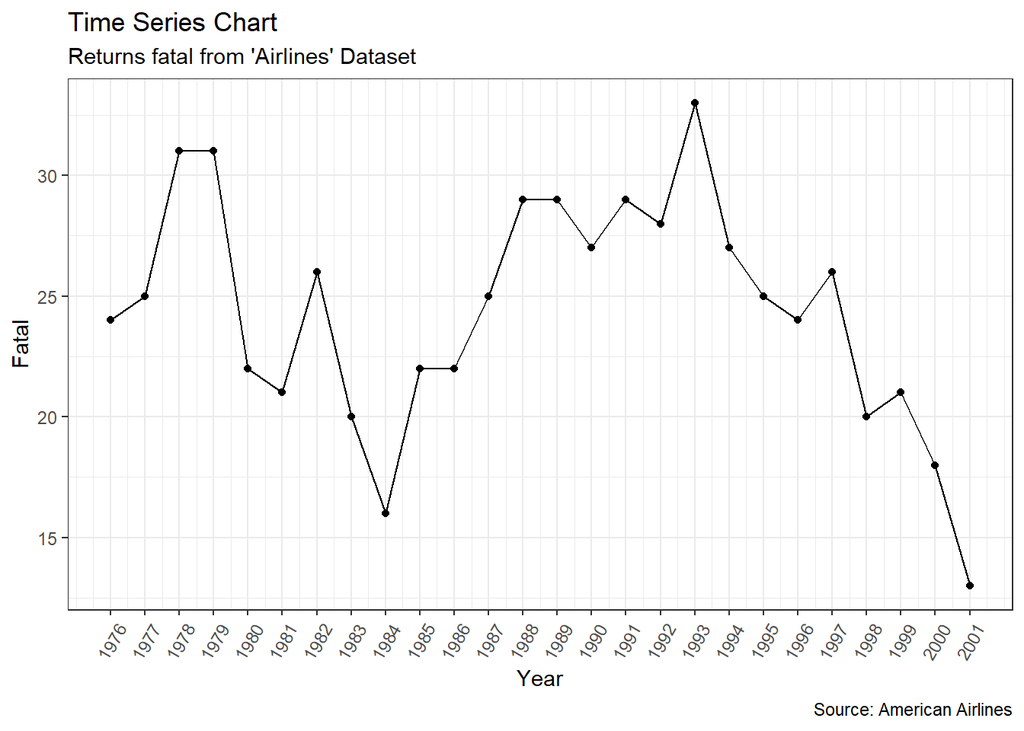

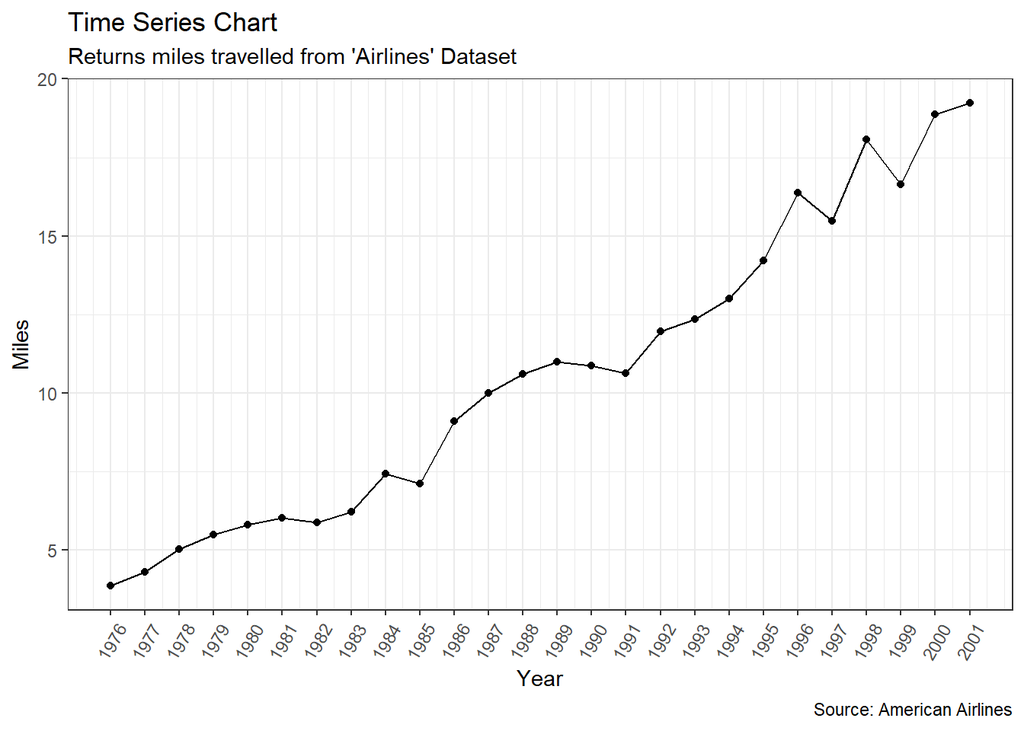

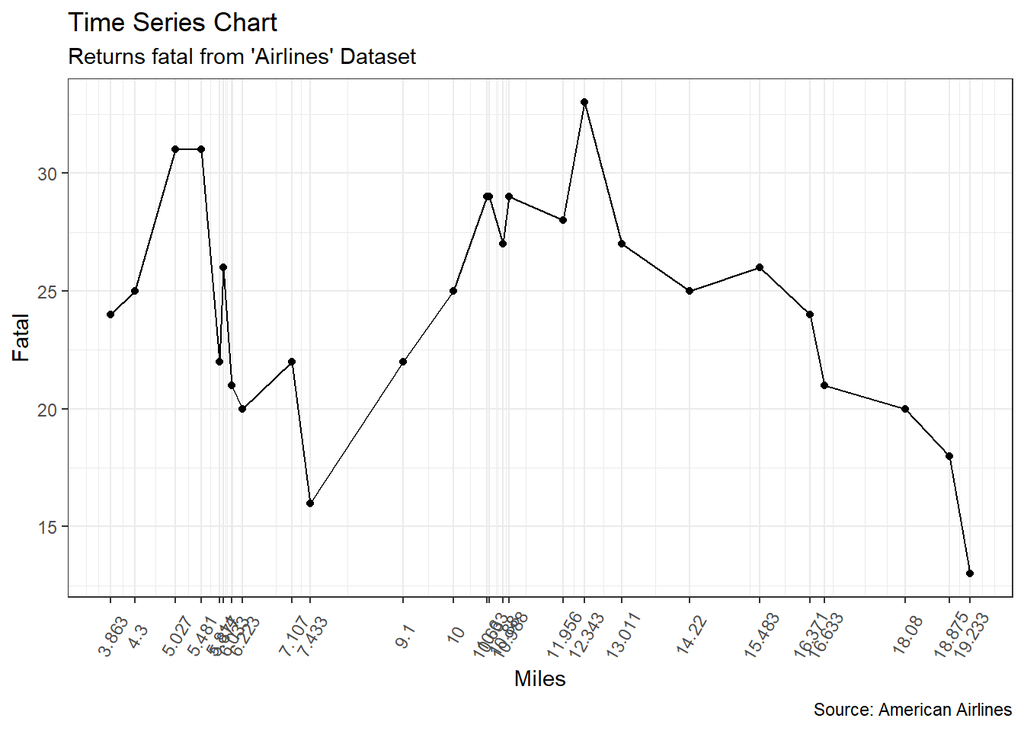

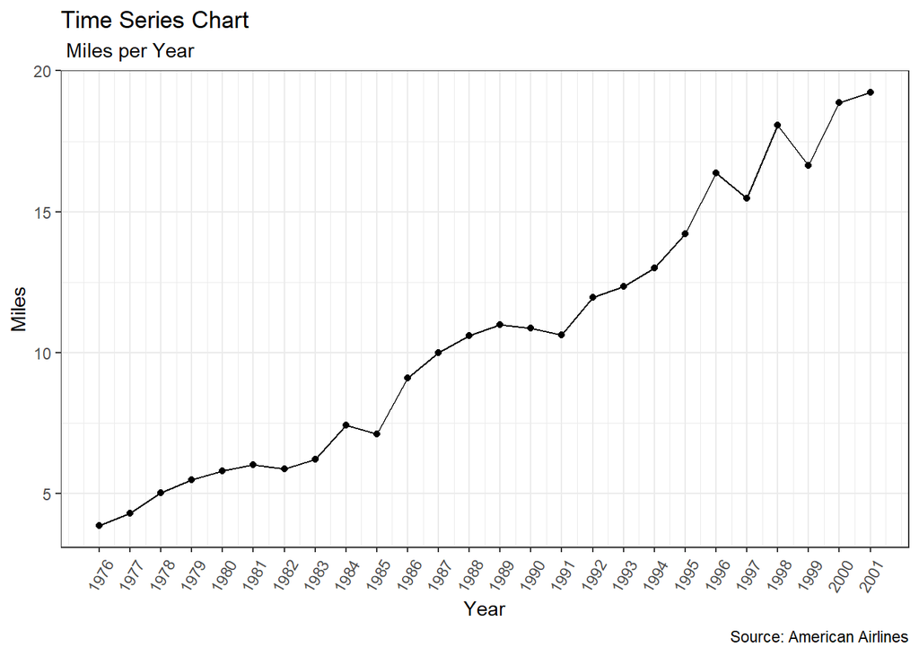

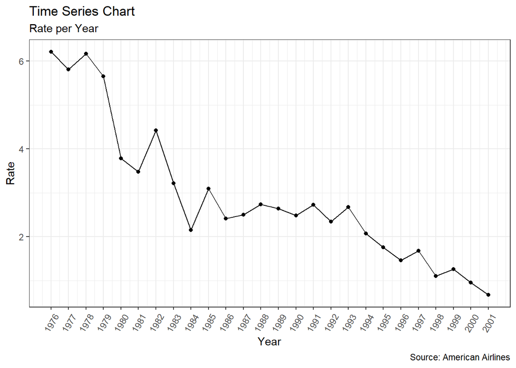

# JAGS MODELS:

## First model

```r
cat( "model {
  for( i in 1:I ) {
    fatal[i] ~ dpois(mu)
    }
    mu ~ dgamma(0.01,0.01)
  }", file="a1.jag" )

a1.par <- c("mu","fatal[27]","fatal[28]","fatal[29]")

a1.ini <- list(list( mu=22 ),
              list( mu=23 ),
              list( mu=24 ) )

a1.dat <- list( fatal = c(airline$fatal,NA,NA,NA), I=29 )

# Model compilation and burn-in
a1.mod <- jags.model( file = "a1.jag",
                    data = a1.dat,
                    inits = a1.ini,
                    n.chains = 3,
                    n.adapt = 1000 )
update(a1.mod,1000)

# Sampling from the posterior
a1.res <- coda.samples( a1.mod,
                      var = a1.par,
                      n.iter = 10000,
                      thin = 10 )
summary( a1.res )
```

[output not shown]

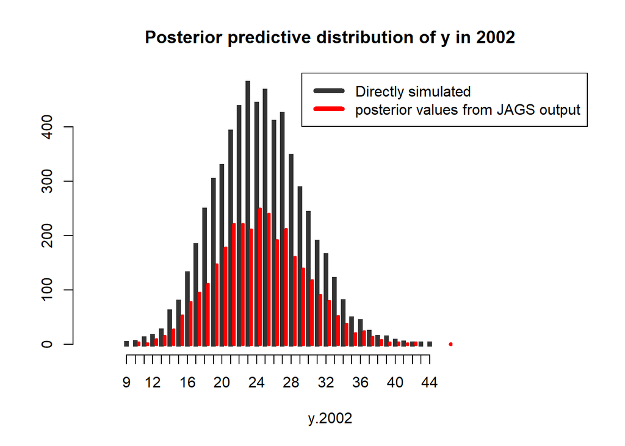

```r
theta <- rgamma(6000, 634, 26 )
y.2002 <- rpois(6000,theta)
plot( main = 'Posterior predictive distribution of y in 2002',table(y.2002), type="h", lwd=5, lend=2, col=gray(0.2), bty="n", ylab="", xlim=c(5,60) )
tpr <- table( as.matrix( a1.res[,"fatal[27]"] ) )
points( as.numeric(names(tpr))+0.4, tpr, type="h", col="red", lwd=4 )
legend("topright", c('Directly simulated','posterior values from JAGS output'),col=c(gray(0.2),'red'),lwd = 5)
```

## Diagnostics for model 1

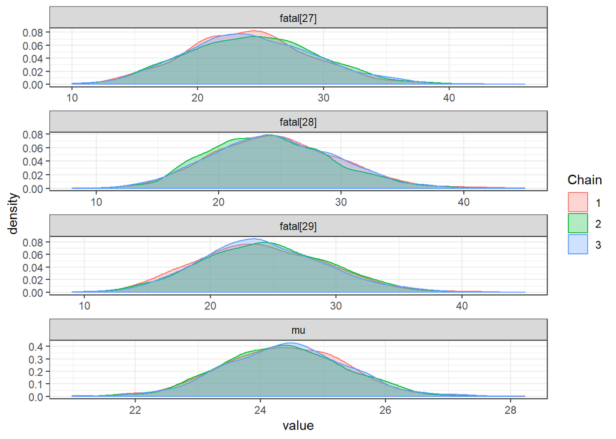

```r
result = ggs(a1.res)
ggs_density(result)
```

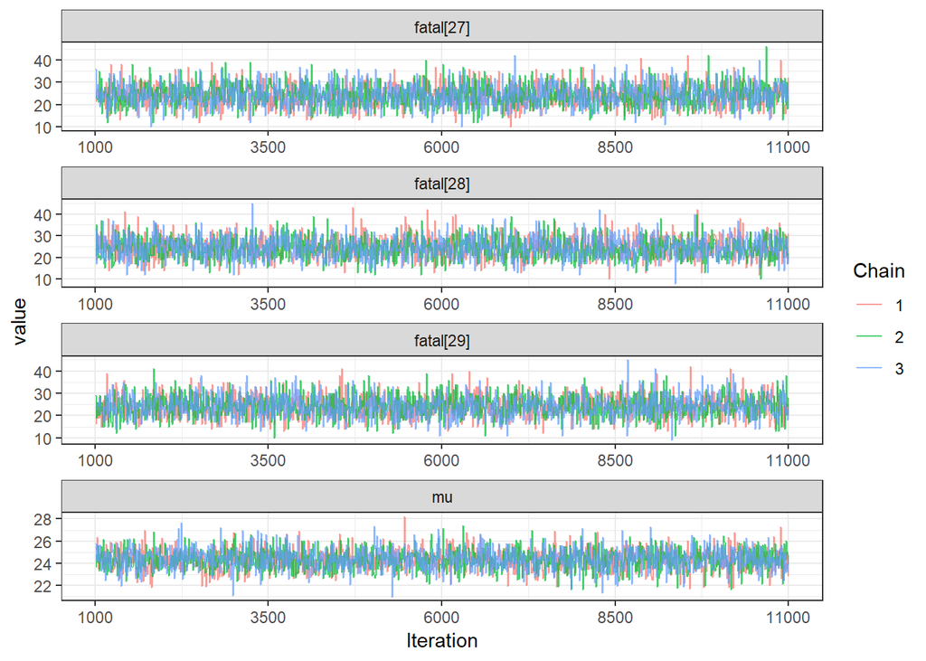

```r
ggs_traceplot(result)
```

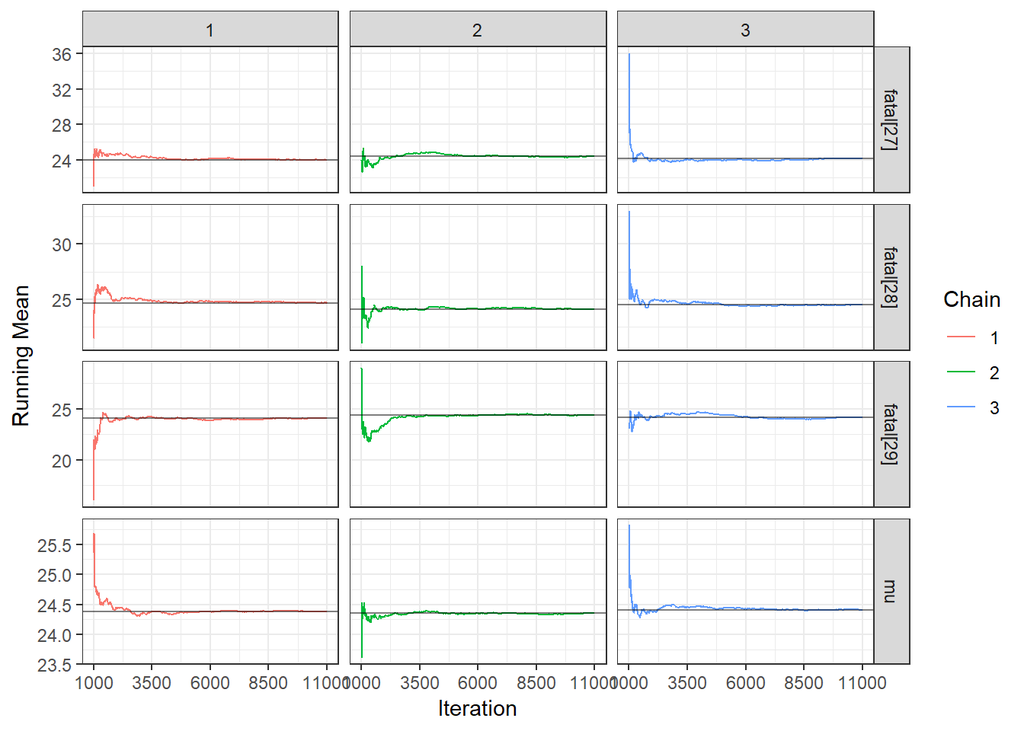

```r
ggs_running(result)
```

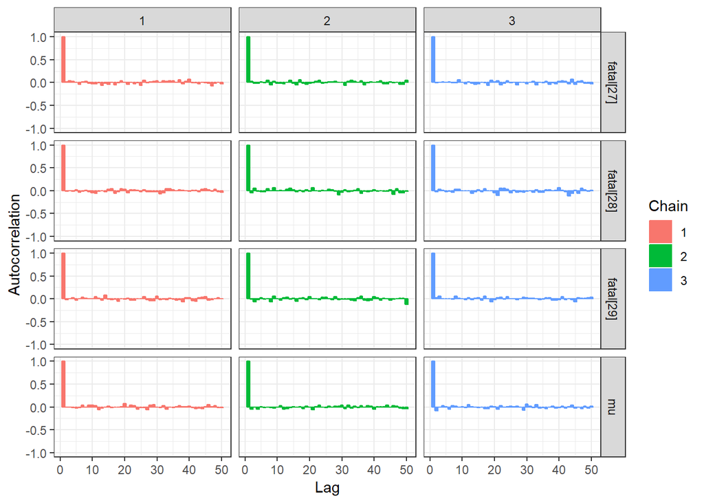

```r
ggs_autocorrelation(result)
```

# Third model

```r
library(rjags)
 cat( "model
 {
 for( i in 1:I )
 {
 fatal[i] ~ dpois( mu[i] )
 log(mu[i]) <- alpha + beta*miles[i]+ beta2 * miles[i]*rate[i]
 }
 alpha ~ dnorm(0,0.0001)
 beta ~ dnorm(0.0001,0.00001)
 beta2 ~ dnorm(0.0001,0.00001)
 }",

 file="a3.jag" )

 a3.ini= list(
    list(alpha = 0.01, beta = 0.6, beta2=0.1),
    list(alpha = 0.2, beta = 0.2, beta2=0.2),
    list(alpha = 0.7, beta = 0.7, beta2=0.3))
 a3.dat <- list( rate= c(airline$rate,0.7080,0.3,0.4),fatal=c(airline$fatal,NA,NA,NA), miles=c(airline$miles,19.775,23.300,20.3), I=29 )
 a3.par <- c("alpha","beta","beta2","fatal[27]","fatal[28]","fatal[29]")

 # Model compilation and burn-in
 a3.mod <- jags.model(file = "a3.jag",data = a3.dat,inits = a3.ini,n.chains = 3,n.adapt = 1000)
 update(a3.mod,1000)
 # Sampling from the posterior
 a3.res <- coda.samples( a3.mod,var = a3.par,n.iter = 10000,thin = 50 )
 summary( a3.res )
```

```
##
## Iterations = 2050:12000
## Thinning interval = 50
## Number of chains = 3
## Sample size per chain = 200
##
## 1. Empirical mean and standard deviation for each variable,
##    plus standard error of the mean:
##
##                Mean       SD  Naive SE Time-series SE
## alpha      2.137679 0.269907 0.0110189      0.0197765
## beta      -0.001293 0.008815 0.0003599      0.0004065
## beta2      0.043062 0.008994 0.0003672      0.0006604
## fatal[27] 15.195000 4.214647 0.1720622      0.1819957
## fatal[28] 11.236667 4.021311 0.1641693      0.1638943
## fatal[29] 11.681667 4.194797 0.1712519      0.1867463
##
## 2. Quantiles for each variable:
##
##               2.5%       25%      50%       75%    97.5%
## alpha      1.60086  1.966235  2.14286  2.324483  2.61235
## beta      -0.01819 -0.006965 -0.00183  0.004859  0.01612
## beta2      0.02729  0.036718  0.04281  0.049329  0.06043
## fatal[27]  8.00000 12.000000 15.00000 18.000000 24.00000
## fatal[28]  4.00000  9.000000 11.00000 14.000000 20.00000
## fatal[29]  5.00000  9.000000 11.00000 14.000000 21.00000
```

## Model 3 diagnostics

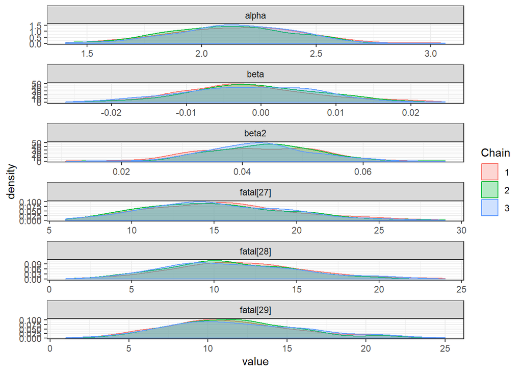

```r
result3 = ggs(a3.res)
ggs_density(result3)
```

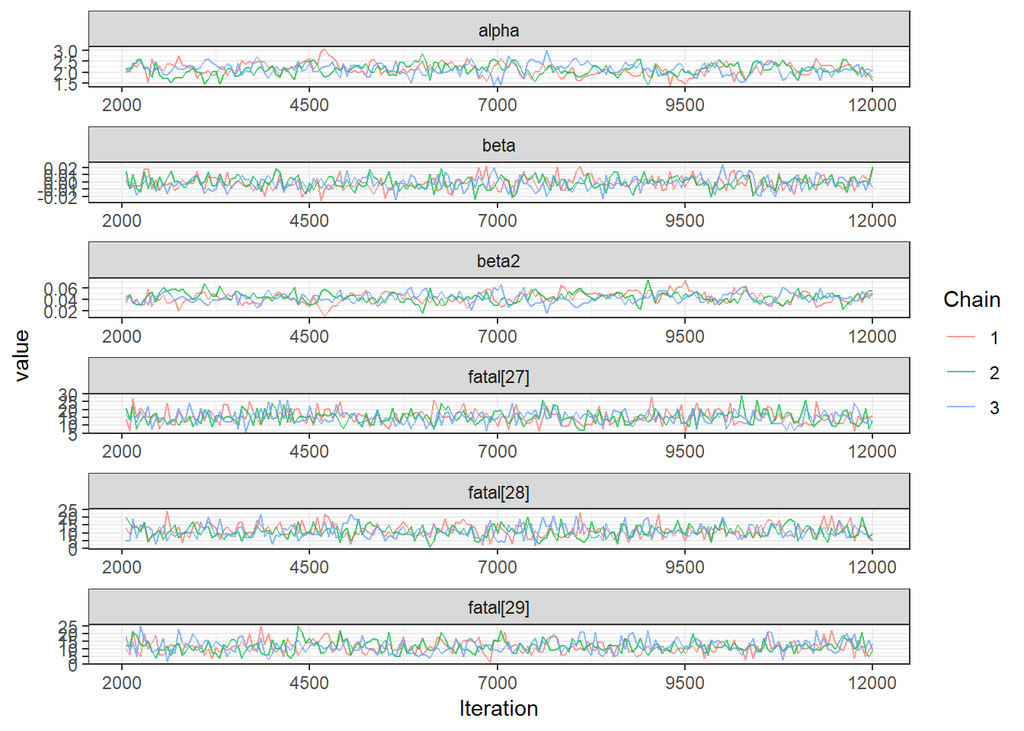

```r
ggs_traceplot(result3)
```

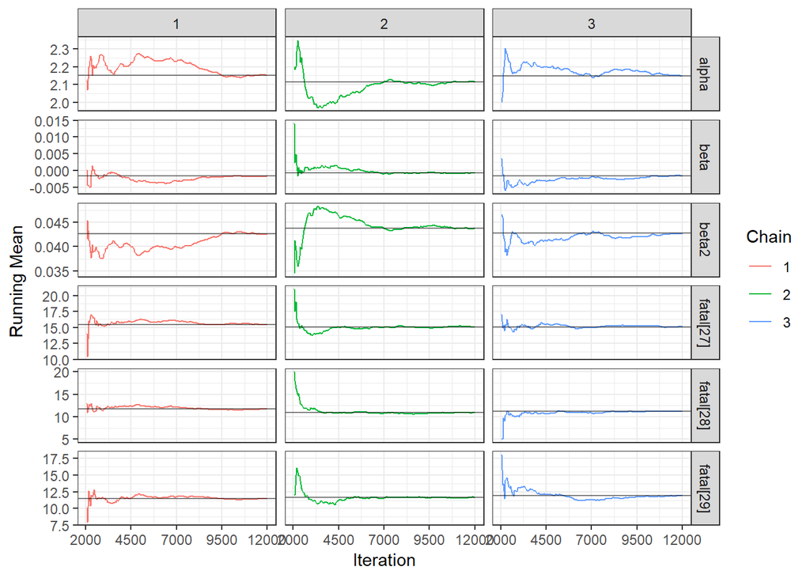

```r
ggs_running(result3)
```

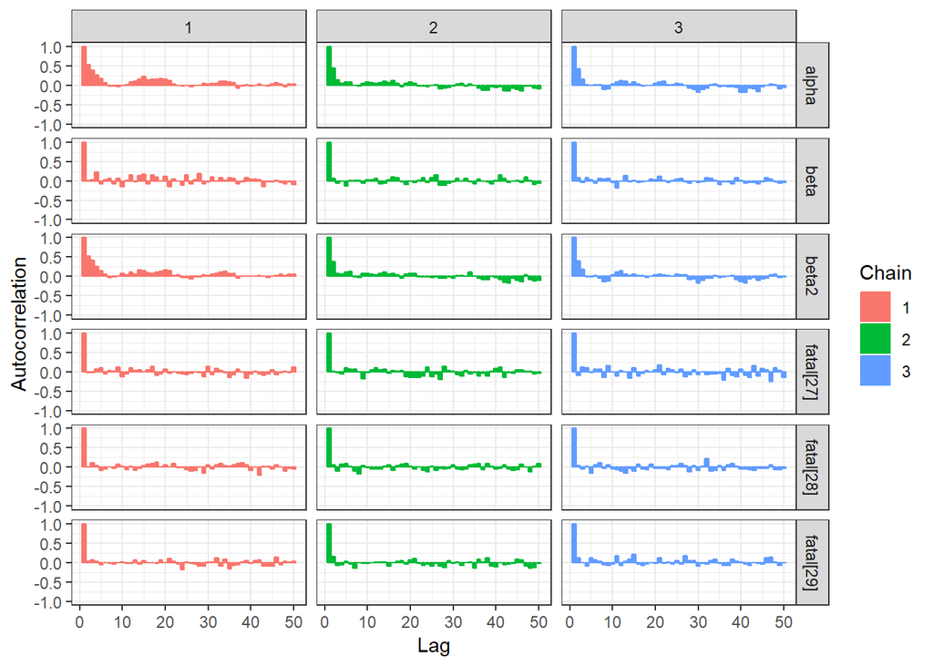

```r
ggs_autocorrelation(result3)
```

## Predicting values in model 3

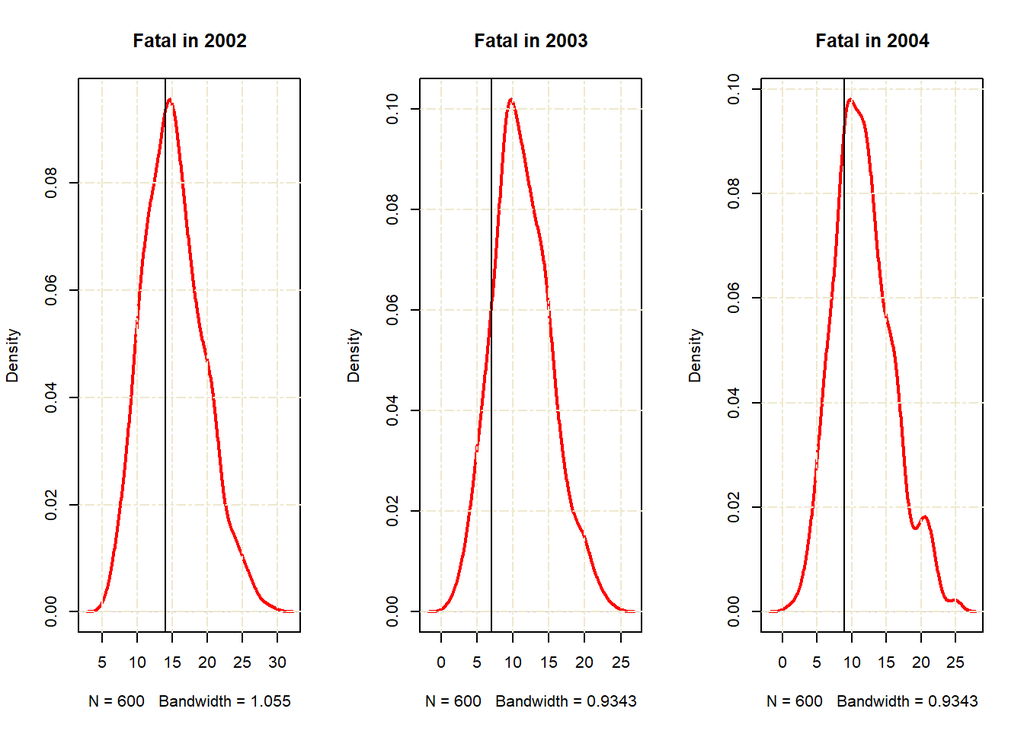

```r
par(mfrow=c(1,3))
a3.m <- as.matrix(a3.res)
plot(density(a3.m[,"fatal[27]"]),main="Fatal in 2002", col="red", lwd=2)
grid (NULL,NULL, lty = 6, col = "cornsilk2")
abline( v=14,col="black")
a3.m <- as.matrix(a3.res)
plot(density(a3.m[,"fatal[28]"]),main="Fatal in 2003", col="red", lwd=2)
grid (NULL,NULL, lty = 6, col = "cornsilk2")
abline( v=7,col="black")
a3.m <- as.matrix(a3.res)
plot(density(a3.m[,"fatal[29]"]),main="Fatal in 2004", col="red", lwd=2)
grid (NULL,NULL, lty = 6, col = "cornsilk2")
abline( v=9,col="black")
```

## Forth model

```r
library(rjags)
 cat( "model
 {
 for( i in 1:I )
 {
 fatal[i] ~ dpois( mu[i] )
 log(mu[i]) <- alpha + beta2 * miles[i]*rate[i]
 }
 alpha ~ dnorm(0,0.0001)

 beta2 ~ dnorm(0.0001,0.00001)
 }",

 file="a4.jag" )

 a4.ini= list(
    list(alpha = 0.01, beta2=0.1),
    list(alpha = 0.2, beta2=0.2),
    list(alpha = 0.7,  beta2=0.3))
 a4.dat <- list( rate= c(airline$rate,0.7080,0.3,0.4),fatal=c(airline$fatal,NA,NA,NA), miles=c(airline$miles,19.775,23.300,20.3), I=29 )
 a4.par <- c("alpha","beta2","fatal[27]","fatal[28]","fatal[29]")

 # Model compilation and burn-in
 a4.mod <- jags.model(file = "a4.jag",data = a4.dat,inits = a4.ini,n.chains = 3,n.adapt = 1000)
 update(a4.mod,1000)
 # Sampling from the posterior
 a4.res <- coda.samples( a4.mod,var = a4.par,n.iter = 10000,thin = 50 )
 summary( a4.res )
```

```
##
## Iterations = 2050:12000
## Thinning interval = 50
## Number of chains = 3
## Sample size per chain = 200
##
## 1. Empirical mean and standard deviation for each variable,
##    plus standard error of the mean:
##
##               Mean       SD  Naive SE Time-series SE
## alpha      2.15271 0.234371 0.0095681      0.0163429
## beta2      0.04188 0.009048 0.0003694      0.0006041
## fatal[27] 15.67667 4.272690 0.1744318      0.1867068
## fatal[28] 11.90500 4.071478 0.1662174      0.1909415
## fatal[29] 12.34333 4.080425 0.1665827      0.2144396
##
## 2. Quantiles for each variable:
##
##              2.5%      25%     50%      75%    97.5%
## alpha     1.71072  1.98456  2.1538  2.30573  2.60376
## beta2     0.02415  0.03572  0.0419  0.04812  0.05802
## fatal[27] 7.00000 13.00000 16.0000 18.00000 24.00000
## fatal[28] 5.00000  9.00000 12.0000 15.00000 21.00000
## fatal[29] 6.00000 10.00000 12.0000 15.00000 21.00000
```

## Model 4 diagnostics

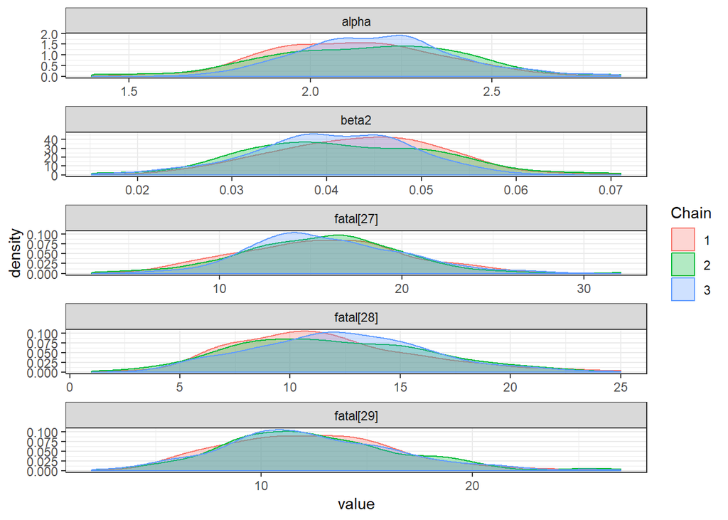

```r
result4 = ggs(a4.res)
ggs_density(result4)
```

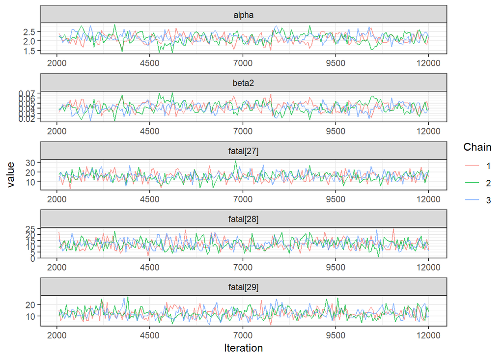

```r
ggs_traceplot(result4)
```

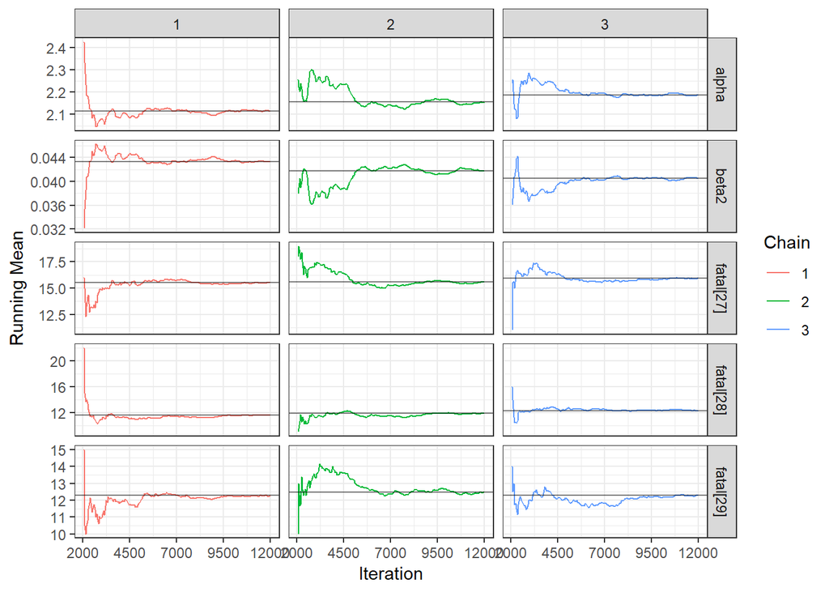

```r
ggs_running(result4)
```